# SPARK SQL (CLOUDS Fall 2018)

### Question 4.5

Plot a bar chart to show the percentage of delayed flights over months in a year. Discuss your findings from the figure.

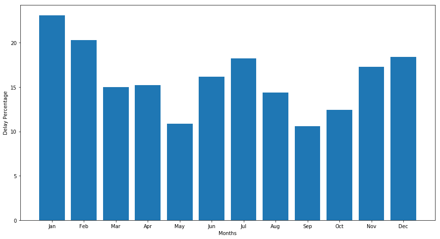

```python
delayRate=delayedFlightsDF.groupBy(['month']).agg(((func.sum('delayedOrNot')/func.count('*'))*100).alias('monthwise_delay_rate')).orderBy('month').collect()
plt.figure(figsize=(15,8))
plt.bar([x for x in range(len(delayRate))], [x[1] for x in delayRate])
plt.xlabel("Months")
plt.ylabel("Delay Percentage")
plt.xticks([x for x in range(12)], ['Jan','Feb','Mar', 'Apr', 'May', 'Jun', 'Jul', 'Aug', 'Sep', 'Oct', 'Nov', 'Dec'])
plt.show()
```

```python
print('It appears May and September experience least delays, but Jan and Feb experience most delays, maybe it has do with winter weather conditions and July is also a bit more probably because the crowd is most in that time ')
```

```
It appears May and September experience least delays, but Jan and Feb experience most delays, maybe it has do with winter weather conditions and July is also a bit more probably because the crowd is most in that time
```

We are ready now to draw some observations from our data, even if we have only looked at data coming from a year worth of flights:

- The probability for a flight to be delayed is low at the beginning or at the very end of a given months
- Flights on two first weekdays and on the weekend, are less likely to be delayed
- May and September are very good months for travelling, as the probability of delay is low (remember we're working on US data. Do you think this is also true in France?)

Putting things together, we can have a global picture of the whole year!

```python
df_with_delay = df.withColumn('is_delay', func.when(df["arrival_delay"] >= 15, 1).otherwise(0))
statistic_day = df_with_delay.groupBy(['year','month', 'day_of_month', 'day_of_week'])\
    .agg((func.sum('is_delay')/func.count('*')).alias('delay_ratio'))

# assume that we do statistic on year 1994
statistic_day = statistic_day\
    .orderBy('year', 'month', 'day_of_month', 'day_of_week')
pdf = pd.DataFrame(data=statistic_day.collect())
```

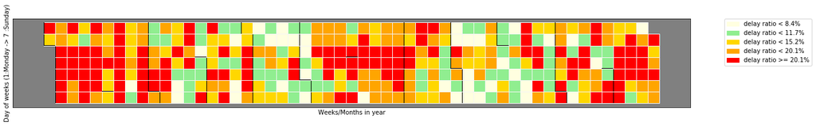

```python
fig = plt.figure(figsize=(20,10))
ax = fig.add_subplot(1,1,1)
plt.xlabel("Weeks/Months in year")
plt.ylabel("Day of weeks (1:Monday -> 7 :Sunday)")
#plt.title('Figure 10: The change of number flights over days in year')

rec_size = 0.3
from matplotlib.patches import Rectangle
import datetime
num_days = len(pdf[0])
ax.patch.set_facecolor('gray')
ax.set_aspect('equal', 'box')
ax.xaxis.set_major_locator(plt.NullLocator())
ax.yaxis.set_major_locator(plt.NullLocator())

for i in range(0, num_days):
    # extract information from the result
    year = pdf[0][i]
    month = pdf[1][i]
    day_of_month = pdf[2][i]
    day_of_week = pdf[3][i]
    day_of_year= datetime.date(year=year, month=month, day=day_of_month).timetuple()
    week_of_year = datetime.date(year=year, month=month, day=day_of_month).isocalendar()[1]

    # dealing with the week of the previous year
    if week_of_year == 52 and month == 1:
        week_of_year = 0

    # the coordinate of a day in graph
    X = week_of_year*rec_size
    Y = day_of_week*rec_size

    # use different colors to show the delay ratio
    color = 'white'
    if pdf[4][i] <= 0.084:
        color = 'lightyellow'
    elif pdf[4][i] <= 0.117:
        color = 'lightgreen'
    elif pdf[4][i] <= 0.152:
        color = 'gold'
    elif pdf[4][i] <= 0.201:
        color = 'orange'
    else:
        color = 'red'
    rect = plt.Rectangle((X - rec_size/2.0, Y - rec_size/2.0), rec_size, rec_size,
                      alpha=1, facecolor=color, edgecolor='whitesmoke')

    ax.add_patch(rect)

    # drawing boders to separate months
    if day_of_month <= 7:
        rect2 = plt.Rectangle((X -rec_size/2.0, Y - rec_size/2.0), 0.01, rec_size,
                      alpha=1, facecolor='black')
        ax.add_patch(rect2)
    if day_of_month == 1:
        rect2 = plt.Rectangle((X - rec_size/2.0, Y - rec_size/2.0), rec_size, 0.01,
                      alpha=1, facecolor='black')
        ax.add_patch(rect2)
ax.autoscale_view()

patch1 = mpatches.Patch(color='lightyellow', label='delay ratio < 8.4%')
patch2 = mpatches.Patch(color='lightgreen', label='delay ratio < 11.7%')
patch3 = mpatches.Patch(color='gold', label='delay ratio < 15.2%')
patch4 = mpatches.Patch(color='orange', label='delay ratio < 20.1%')
patch5 = mpatches.Patch(color='red', label='delay ratio >= 20.1%')

plt.legend(handles=[patch1, patch2, patch3, patch4, patch5], bbox_to_anchor=(1.05, 1), loc=2, borderaxespad=0.)

plt.show()
```

### Question 4.6

What is the delay probability for the top 20 busiest airports? By drawing the flight volume of each airport and the associated delay probability in a single plot, we can observe the relationship between airports, number of flights and the delay.

HINT

Function `.isin()` helps checking whether a value in column belongs to a list.

SUGGESTION

You can try with different chart type to have a better visualization.

```python
unionDf=df.withColumn('airport', df.src_airport).union(df.withColumn('airport', df.dest_airport))
busiestAirports=unionDf.groupBy('airport').count().orderBy('count', ascending=0)
top20_busiestAirports= busiestAirports.take(20)
top20_busiestAirports= [x[0] for x in top20_busiestAirports]
print(top20_busiestAirports)
```

```
['ORD', 'DFW', 'ATL', 'LAX', 'STL', 'DEN', 'PHX', 'DTW', 'PIT', 'CLT', 'MSP', 'SFO', 'EWR', 'IAH', 'LGA', 'BOS', 'LAS', 'PHL', 'DCA', 'MCO']
```

```python
df_with_delay = unionDf.filter(unionDf.airport.isin(top20_busiestAirports)).withColumn('is_delay', func.when((df["arrival_delay"] >= 15), 1).otherwise(0))
delayRate = df_with_delay.groupBy('airport')\
                 .agg((func.sum('is_delay')/func.count('*')).alias('delay_rate'))\
                 .orderBy('delay_rate')
print("Delay Probability of top 20 busiest airports: ")
delayRate.show()
delayRate.collect()
```

```
Delay Probability of top 20 busiest airports:
+-------+-------------------+
|airport|         delay_rate|
+-------+-------------------+
|    MSP|0.13999112831679975|
|    DTW|0.14818729368158917|
|    ORD| 0.1556564035614228|
|    DCA|0.16124691252874543|
|    PHX|0.16685201026518393|
|    IAH|0.16711171622936752|
|    STL|0.16954820652477423|
|    LAS|0.17209877843302443|
|    MCO|0.17871454592766067|
|    SFO|  0.184632959342274|
|    LAX|0.18532695062538138|
|    LGA| 0.1854427080772219|
|    CLT|0.18741529078363725|
|    PIT|0.19441011032977232|
|    DEN| 0.1950330267646379|
|    DFW|0.20272088561399976|
|    PHL|0.20326168959373345|
|    ATL|0.20877099536420554|
|    BOS|0.21722017466549154|
|    EWR| 0.2611980802680445|
+-------+-------------------+
```

```
[Row(airport='MSP', delay_rate=0.13999112831679975),
 Row(airport='DTW', delay_rate=0.14818729368158917),
 Row(airport='ORD', delay_rate=0.1556564035614228),
 Row(airport='DCA', delay_rate=0.16124691252874543),
 Row(airport='PHX', delay_rate=0.16685201026518393),
 Row(airport='IAH', delay_rate=0.16711171622936752),
 Row(airport='STL', delay_rate=0.16954820652477423),
 Row(airport='LAS', delay_rate=0.17209877843302443),
 Row(airport='MCO', delay_rate=0.17871454592766067),
 Row(airport='SFO', delay_rate=0.184632959342274),
 Row(airport='LAX', delay_rate=0.18532695062538138),
 Row(airport='LGA', delay_rate=0.1854427080772219),
 Row(airport='CLT', delay_rate=0.18741529078363725),
 Row(airport='PIT', delay_rate=0.19441011032977232),
 Row(airport='DEN', delay_rate=0.1950330267646379),
 Row(airport='DFW', delay_rate=0.20272088561399976),
 Row(airport='PHL', delay_rate=0.20326168959373345),
 Row(airport='ATL', delay_rate=0.20877099536420554),
 Row(airport='BOS', delay_rate=0.21722017466549154),
 Row(airport='EWR', delay_rate=0.2611980802680445)]
```

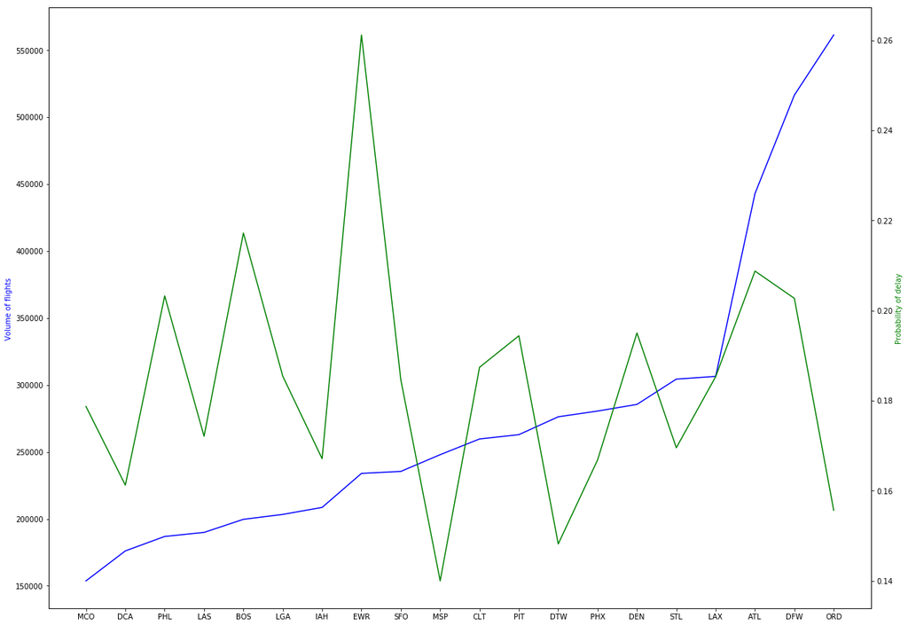

```python
busyAirportsAndDelay = busiestAirports.join(delayRate, on='airport').select('*').orderBy('count').collect()

#Line Graph
fig = plt.figure(figsize=(20,15))
ax = fig.add_subplot(1,1,1)
ax.plot([x for x in range(len(busyAirportsAndDelay))], [x[1] for x in busyAirportsAndDelay],color='b')
ax.set_ylabel('Volume of flights ',color='b')
ax2 = ax.twinx()
ax2.plot([x for x in range(len(busyAirportsAndDelay))], [x[2] for x in busyAirportsAndDelay],color='g')
ax2.set_ylabel('Probability of delay',color='g')
plt.xticks([x for x in range(len(busyAirportsAndDelay))], [x[0] for x in busyAirportsAndDelay])
#plt.title('Delay probability and flight volume of 20 busiest airports')
plt.show()
```

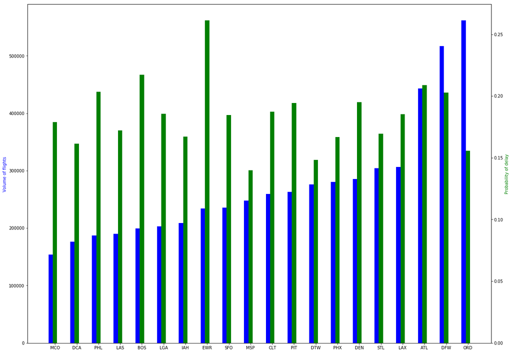

```python
#Bar Graph
fig = plt.figure(figsize=(20,15))
ax = fig.add_subplot(1,1,1)
ax.bar([x for x in range(len(busyAirportsAndDelay))], [x[1] for x in busyAirportsAndDelay],color='b',width=-0.2)
ax.set_ylabel('Volume of flights ',color='b')
ax2 = ax.twinx()
ax2.bar([x+0.2 for x in range(len(busyAirportsAndDelay))], [x[2] for x in busyAirportsAndDelay],color='g',width=-0.2)
ax2.set_ylabel('Probability of delay',color='g')
plt.xticks([x+0.2 for x in range(len(busyAirportsAndDelay))], [x[0] for x in busyAirportsAndDelay])
#plt.title('Delay probability and flight volume of 20 busiest airports')
plt.show()
```

### Question 4.7

What is the percentage of delayed flights which belong to one of the top 20 busiest carriers? Comment the figure!

SUGGESTION

You can try with different chart type to have a better visualization.

```python
busiestCarriers=df.groupBy('carrier').count().orderBy('count', ascending=0)
top20_busiestCarriers= busiestCarriers.take(20)
top20_busiestCarriers= [x[0] for x in top20_busiestCarriers]
print(top20_busiestCarriers)
```

```
['DL', 'US', 'AA', 'UA', 'WN', 'CO', 'NW', 'TW', 'HP', 'AS']
```

```python
df_with_delay = df.filter(df.carrier.isin(top20_busiestCarriers)).withColumn('is_delay', func.when((df["arrival_delay"] >= 15), 1).otherwise(0))
delayRate = df_with_delay.groupBy('carrier')\
                 .agg((func.sum('is_delay')/func.count('*')).alias('delay_rate'))\
                 .orderBy('delay_rate')
print("Delay Probability of top 20 busiest carriers: ")
delayRate.show()
delayRate.collect()
```

```
Delay Probability of top 20 busiest carriers:
+-------+-------------------+
|carrier|         delay_rate|
+-------+-------------------+
|     WN|0.12829795587751536|
|     NW| 0.1294806523639286|
|     AS| 0.1596424771227921|
|     UA| 0.1686528375733855|
|     AA| 0.1752444006939166|
|     TW|0.18212273193780135|
|     DL|0.18328443065157582|
|     US|0.18422298014001534|
|     HP|0.18625141269939444|
|     CO| 0.1955576547849367|
+-------+-------------------+
```

```
[Row(carrier='WN', delay_rate=0.12829795587751536),
 Row(carrier='NW', delay_rate=0.1294806523639286),
 Row(carrier='AS', delay_rate=0.1596424771227921),
 Row(carrier='UA', delay_rate=0.1686528375733855),
 Row(carrier='AA', delay_rate=0.1752444006939166),
 Row(carrier='TW', delay_rate=0.18212273193780135),
 Row(carrier='DL', delay_rate=0.18328443065157582),
 Row(carrier='US', delay_rate=0.18422298014001534),
 Row(carrier='HP', delay_rate=0.18625141269939444),
 Row(carrier='CO', delay_rate=0.1955576547849367)]
```

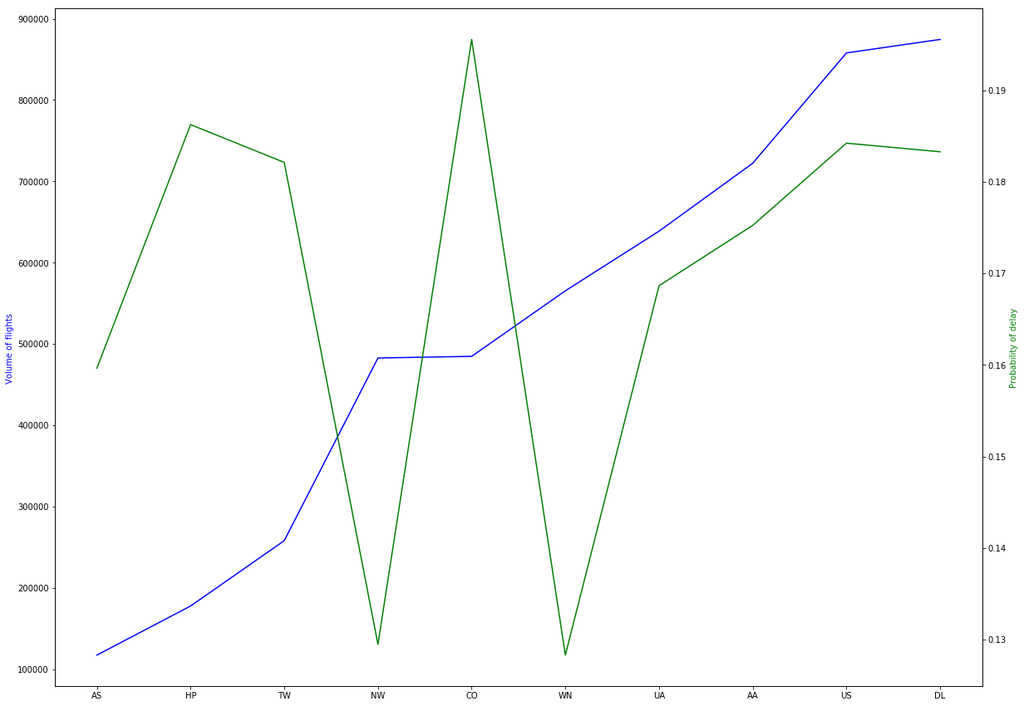

```python
busyCarriersAndDelay = busiestCarriers.join(delayRate, on='carrier').select('*').orderBy('count').collect()

#Line Graph
fig = plt.figure(figsize=(20,15))
ax = fig.add_subplot(1,1,1)
ax.plot([x for x in range(len(busyCarriersAndDelay))], [x[1] for x in busyCarriersAndDelay],color='b')
ax.set_ylabel('Volume of flights ',color='b')
ax2 = ax.twinx()
ax2.plot([x for x in range(len(busyCarriersAndDelay))], [x[2] for x in busyCarriersAndDelay],color='g')
ax2.set_ylabel('Probability of delay',color='g')
plt.xticks([x for x in range(len(busyCarriersAndDelay))], [x[0] for x in busyCarriersAndDelay])
#plt.title('Delay probability and flight volume of 20 busiest carriers')
plt.show()
```

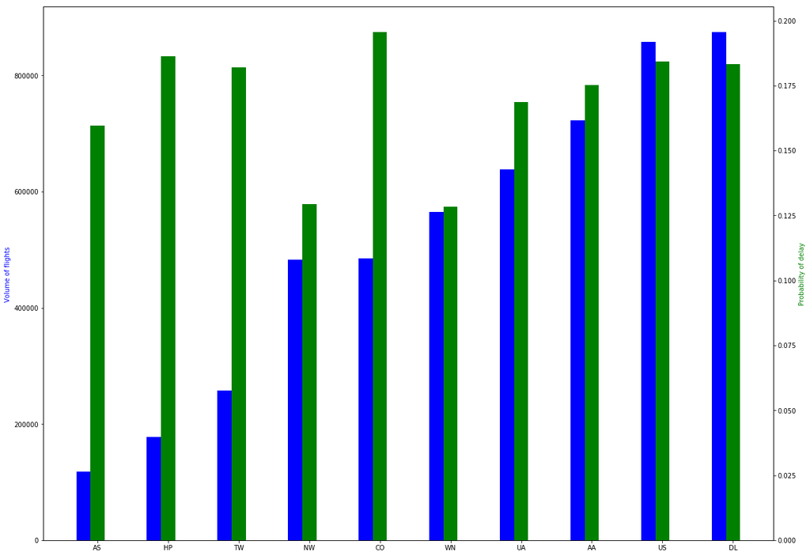

```python
#Bar Graph
fig = plt.figure(figsize=(20,15))
ax = fig.add_subplot(1,1,1)
ax.bar([x for x in range(len(busyCarriersAndDelay))], [x[1] for x in busyCarriersAndDelay],color='b',width=0.2)
ax.set_ylabel('Volume of flights ',color='b')
ax2 = ax.twinx()
ax2.bar([x+0.2 for x in range(len(busyCarriersAndDelay))], [x[2] for x in busyCarriersAndDelay],color='g',width=0.2)
ax2.set_ylabel('Probability of delay',color='g')
plt.xticks([x+0.2 for x in range(len(busyCarriersAndDelay))], [x[0] for x in busyCarriersAndDelay])
#plt.title('Delay probability and flight volume of 20 busiest carriers')
plt.show()
```

## Addition (bonus) questions

### Additional data

In the HDFS file system you have used for running the Notebook, you will notice that there are several other years available (in addition to 1994).

There are some other datasets that related to this use case:

- Airport IATA Codes to City names and Coordinates mapping: http://stat-computing.org/dataexpo/2009/airports.csv
- Carrier codes to Full name mapping: http://stat-computing.org/dataexpo/2009/carriers.csv
- Information about individual planes: http://stat-computing.org/dataexpo/2009/plane-data.csv
- Weather information: http://www.wunderground.com/weather/api/. You can subscribe for free to the developers' API and obtain (at a limited rate) historical weather information in many different formats. Also, to get an idea of the kind of information is available, you can use this link: http://www.wunderground.com/history/

### Question 5.1

Which airports are present in the dataset only as destination airport? Which airport is present only as source airport in the dataset?

### Question 5.2

Which airports have biggest delay probability ? Which cities have largest delay duration in average ?

### Question 5.3

Is there any relationship between weather condition and the delay of flights in 1994 ?